# **Problem Statement**

## Business Context

Vehicle breakdowns and engine failures lead to significant financial losses for both individual owners and fleet operators. Unexpected engine failures can cause expensive repairs, operational downtime, and safety risks. Predictive maintenance in the automotive industry can help minimize these issues by leveraging sensor data to forecast potential failures before they occur.

Automobile manufacturers, fleet managers, and service providers aim to develop data-driven solutions to improve engine reliability and optimize maintenance schedules. By analyzing engine health parameters such as RPM, temperature, pressure, and other sensor readings, machine learning models can be trained to predict when an engine requires maintenance, allowing proactive intervention before a failure occurs.

The sensor values in the dataset are consistent with the operating parameters of larger and small engines commonly found in equipment like Vechiles, lawnmowers, portable generators, and compact machinery. Some engines operate at lower RPMs, pressures, and temperatures compared to larger automotive engines and vice versa. Therefore, the data is appropriate for developing predictive maintenance models tailored to large and small engine applications.

## Objective

As a Data Scientist, your goal is to build a predictive maintenance model that can analyze historical and real-time engine sensor data to identify potential failures. The model should accurately classify whether an engine requires maintenance or is operating normally.

This solution will help:

- Reduce unplanned breakdowns and costly repairs.
  - Improve vehicle performance and engine lifespan.
  - Optimize maintenance schedules to minimize downtime
  - Provide data-driven insights to manufacturers and fleet operators for better decision-making.

By implementing a robust predictive maintenance system, this solution can lead to significant cost savings and improved efficiency in the automotive sector.

## Data Description

- **Engine_RPM**: The number of revolutions per minute (RPM) of the engine, indicating engine speed. It is defined in Revolutions per Minute (RPM).
- Lub_Oil_Pressure: The pressure of the lubricating oil in the engine, essential for reducing friction and wear. It is defined in bar or kilopascals (kPa)
- **Fuel_Pressure**: The pressure at which fuel is supplied to the engine, critical for proper combustion. It is defined in bar or kilopascals (kPa)
- **Coolant_Pressure**: The pressure of the engine coolant, affecting engine temperature regulation. It is defined in bar or kilopascals (kPa)
- **Lub_Oil_Temperature**: The temperature of the lubricating oil, which impacts viscosity and engine performance. It is defined in degrees Celsius (°C)
- **Coolant_Temperature**: The temperature of the engine coolant, crucial for preventing overheating. It is defined in degrees Celsius (°C)
- **Engine_Condition**: A categorical or numerical label representing the health of the engine, potentially indicating normal operation or various levels of wear and failure risks. It is defined as a categorical variable (0/1) representing a state such as "0 = Off/False/Active" and "1 = On/True/Faulty"

# Predictive Maintenance for Engine Health – Detailed EDA & Modeling

## 1. Import Libraries

```python
import warnings
warnings.filterwarnings("ignore")

# Libraries to help with reading and manipulating data
import numpy as np
import pandas as pd

# For splitting the dataset
from sklearn.model_selection import train_test_split
from sklearn.impute import SimpleImputer
from sklearn import metrics

# Libaries to help with data visualization
import matplotlib.pyplot as plt
import seaborn as sns

# Removes the limit for the number of displayed columns
pd.set_option("display.max_columns", None)
# Sets the limit for the number of displayed rows
pd.set_option("display.max_rows", 100)


# Libraries different ensemble classifiers
from sklearn.ensemble import (
    BaggingRegressor,
    RandomForestRegressor,
    AdaBoostRegressor,
    GradientBoostingRegressor,
)
from xgboost import XGBRegressor
from sklearn.tree import DecisionTreeRegressor

# Libraries to get different metric scores
from sklearn.metrics import (
    confusion_matrix,
    accuracy_score,
    precision_score,
    recall_score,
    f1_score,
    mean_squared_error,
    mean_absolute_error,
    r2_score,
    mean_absolute_percentage_error
)

# To create the pipeline
from sklearn.compose import make_column_transformer
from sklearn.pipeline import make_pipeline,Pipeline

# To tune different models and standardize
from sklearn.model_selection import GridSearchCV
from sklearn.preprocessing import StandardScaler,OneHotEncoder

# To serialize the model
import joblib

# os related functionalities
import os

# API request
import requests

# for hugging face space authentication to upload files
from huggingface_hub import login, HfApi
from huggingface_hub import snapshot_download
```

# Task

Create a 'data' folder, move the `engine_data.csv` file into it, and then register the dataset on Hugging Face by uploading the 'data' folder to a new Hugging Face dataset repository named "predictive-maintenance-engine-health-dataset".

## Create Data Folder Structure

### Subtask:

Create a master folder and a 'data' subfolder within it to organize the dataset files. This ensures a clean and structured environment for data management.

```python
import os
import shutil

# Create a new directory named 'data' if it doesn't already exist
data_folder = 'data'
os.makedirs(data_folder, exist_ok=True)
print(f"Directory '{data_folder}' ensured to exist.")

# Define the source and destination paths for the dataset file
source_file = 'engine_data.csv'
destination_file = os.path.join(data_folder, source_file)

# Move the 'engine_data.csv' file into the 'data' directory
# Check if the file exists in the current directory before moving
if os.path.exists(source_file):
    shutil.move(source_file, destination_file)
    print(f"Moved '{source_file}' to '{data_folder}/'")
else:
    print(f"'{source_file}' not found in current directory. Assuming it's already in '{data_folder}' or previously moved.")
```

```
Directory 'data' ensured to exist.
'engine_data.csv' not found in current directory. Assuming it's already in 'data' or previously moved.
```

## Register Dataset on Hugging Face

```python
from huggingface_hub import login

# Login to Hugging Face account using access token
login(token="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")
```

```python
from huggingface_hub import create_repo

# Define the name of the new dataset repository
dataset_repo_name = "predictive-maintenance-engine-health-dataset"

# Try to create the dataset repository
try:
    create_repo(dataset_repo_name,
        repo_type="dataset",  # Specify the repository type as "dataset"
        private=False  # Set to True if you want the dataset to be private
    )
    print(f"Dataset repository '{dataset_repo_name}' created successfully.")
except Exception as e:
    # Handle potential errors during repository creation, especially if it already exists
    if "RepositoryAlreadyExistsError" in str(e):
        print(f"Dataset repository '{dataset_repo_name}' already exists. Skipping creation.")
    else:
        print(f"Error creating dataset repository '{dataset_repo_name}': {e}")
```

```
Error creating dataset repository 'predictive-maintenance-engine-health-dataset': 409 Client Error: Conflict for url: https://huggingface.co/api/repos/create (Request ID: Root=1-6974d0d9-2006bd2360ba4ccc5e547879;a3f6b98f-2a54-4866-ae30-fa83c1984586)

You already created this dataset repo: VeerendraManikonda/predictive-maintenance-engine-health-dataset
```

```python
from huggingface_hub import HfApi

# Initialize the Hugging Face API
api = HfApi()

# Define the dataset repository ID (username/repo_name)
dataset_repo_id = f"{api.whoami()['name']}/{dataset_repo_name}" # Using the dynamically created dataset_repo_name

# Upload the 'data' folder to the Hugging Face dataset repository
api.upload_folder(
    folder_path="./data",  # Path to the local 'data' folder
    repo_id=dataset_repo_id,  # Hugging Face dataset repository ID
    repo_type="dataset",  # Specify the repository type as 'dataset'
    commit_message="Upload engine_data.csv"
)

print(f"Successfully uploaded 'data' folder to {dataset_repo_id}.")
```

```
No files have been modified since last commit. Skipping to prevent empty commit.
WARNING:huggingface_hub.hf_api:No files have been modified since last commit. Skipping to prevent empty commit.
```

```
Successfully uploaded 'data' folder to VeerendraManikonda/predictive-maintenance-engine-health-dataset.
```

## 2. Load Dataset

```python
# Define the Hugging Face repository ID
repo_id = "VeerendraManikonda/predictive-maintenance-engine-health-dataset"

# Define the local cache directory to save the dataset files
cache_dir = "./hf_dataset_cache"

print(f"Hugging Face repository ID: {repo_id}")
print(f"Local cache directory: {cache_dir}")
```

```
Hugging Face repository ID: VeerendraManikonda/predictive-maintenance-engine-health-dataset
Local cache directory: ./hf_dataset_cache
```

```python
import os
import pandas as pd

# Download the dataset files from Hugging Face
dataset_path = snapshot_download(repo_id=repo_id, cache_dir=cache_dir, repo_type='dataset')

# Construct the full path to the engine_data.csv file
# Corrected path: Assuming the file is directly in the root of the downloaded dataset_path
csv_file_path = os.path.join(dataset_path, 'engine_data.csv')

# Load the engine_data.csv file into a pandas DataFrame
df = pd.read_csv(csv_file_path)

# Display the first few rows of the DataFrame to verify the successful load
print(f"Dataset loaded from: {csv_file_path}")
df.head()
```

```
Dataset loaded from: ./hf_dataset_cache/datasets--VeerendraManikonda--predictive-maintenance-engine-health-dataset/snapshots/3c78678ceb40460987fc29576907b84d6124cb26/engine_data.csv
```

|  | Engine rpm | Lub oil pressure | Fuel pressure | Coolant pressure | lub oil temp | Coolant temp | Engine Condition |
| --- | --- | --- | --- | --- | --- | --- | --- |
| 0 | 700 | 2.493592 | 11.790927 | 3.178981 | 84.144163 | 81.632187 | 1 |
| 1 | 876 | 2.941606 | 16.193866 | 2.464504 | 77.640934 | 82.445724 | 0 |
| 2 | 520 | 2.961746 | 6.553147 | 1.064347 | 77.752266 | 79.645777 | 1 |
| 3 | 473 | 3.707835 | 19.510172 | 3.727455 | 74.129907 | 71.774629 | 1 |
| 4 | 619 | 5.672919 | 15.738871 | 2.052251 | 78.396989 | 87.000225 | 0 |

## 3. Data Quality & Preparation

```python
# Print the concise summary of the DataFrame including the index dtype and column dtypes, non-null values and memory usage
df.info()

# Print the description of the DataFrame (statistical summary)
display(df.describe(include='all').T)
```

```
<class 'pandas.core.frame.DataFrame'>
RangeIndex: 19535 entries, 0 to 19534
Data columns (total 7 columns):
 #   Column            Non-Null Count  Dtype
---  ------            --------------  -----
 0   Engine rpm        19535 non-null  int64
 1   Lub oil pressure  19535 non-null  float64
 2   Fuel pressure     19535 non-null  float64
 3   Coolant pressure  19535 non-null  float64
 4   lub oil temp      19535 non-null  float64
 5   Coolant temp      19535 non-null  float64
 6   Engine Condition  19535 non-null  int64
dtypes: float64(5), int64(2)
memory usage: 1.0 MB
```

|  | count | mean | std | min | 25% | 50% | 75% | max |
| --- | --- | --- | --- | --- | --- | --- | --- | --- |
| Engine rpm | 19535.0 | 791.239263 | 267.611193 | 61.000000 | 593.000000 | 746.000000 | 934.000000 | 2239.000000 |
| Lub oil pressure | 19535.0 | 3.303775 | 1.021643 | 0.003384 | 2.518815 | 3.162035 | 4.055272 | 7.265566 |
| Fuel pressure | 19535.0 | 6.655615 | 2.761021 | 0.003187 | 4.916886 | 6.201720 | 7.744973 | 21.138326 |
| Coolant pressure | 19535.0 | 2.335369 | 1.036382 | 0.002483 | 1.600466 | 2.166883 | 2.848840 | 7.478505 |
| lub oil temp | 19535.0 | 77.643420 | 3.110984 | 71.321974 | 75.725990 | 76.817350 | 78.071691 | 89.580796 |
| Coolant temp | 19535.0 | 78.427433 | 6.206749 | 61.673325 | 73.895421 | 78.346662 | 82.915411 | 195.527912 |
| Engine Condition | 19535.0 | 0.630509 | 0.482679 | 0.000000 | 0.000000 | 1.000000 | 1.000000 | 1.000000 |

```python
# Check for missing values
print("Missing values per column:\n", df.isnull().sum())
```

```
Missing values per column:
 Engine rpm          0
Lub oil pressure    0
Fuel pressure       0
Coolant pressure    0
lub oil temp        0
Coolant temp        0
Engine Condition    0
dtype: int64
```

```python
# Check for duplicate rows
print("Number of duplicate rows: ", df.duplicated().sum())
```

```
Number of duplicate rows:  0
```

```python
# Display min and max values for numerical columns
display(df.describe().T[['min', 'max']])
```

|  | min | max |
| --- | --- | --- |
| Engine rpm | 61.000000 | 2239.000000 |
| Lub oil pressure | 0.003384 | 7.265566 |
| Fuel pressure | 0.003187 | 21.138326 |
| Coolant pressure | 0.002483 | 7.478505 |
| lub oil temp | 71.321974 | 89.580796 |
| Coolant temp | 61.673325 | 195.527912 |
| Engine Condition | 0.000000 | 1.000000 |

## 4. Rename Columns

```python
df.columns = [
    'Engine_RPM',
    'Lub_Oil_Pressure',
    'Fuel_Pressure',
    'Coolant_Pressure',
    'Lub_Oil_Temperature',
    'Coolant_Temperature',
    'Engine_Condition'
]
```

## 5. Target Variable Analysis

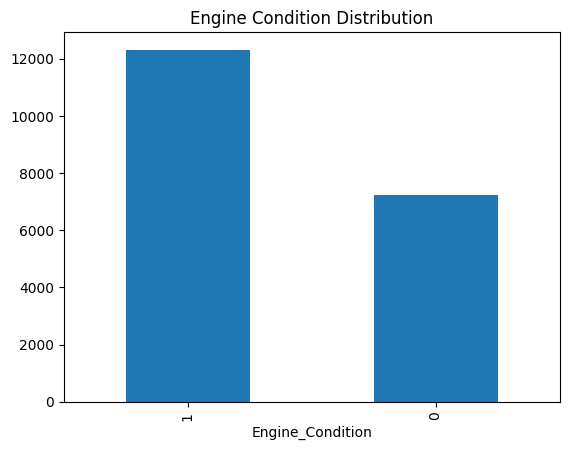

```python
df['Engine_Condition'].value_counts().plot(kind='bar')
plt.title('Engine Condition Distribution')
plt.show()
```

### Observation

# **Exploratory Data Analysis (EDA)**

## 6. Univariate Analysis

```python
def histogram_boxplot(data, feature, figsize=(15, 10), kde=False, bins=None):
    """
    Boxplot and histogram combined

    data: dataframe
    feature: dataframe column
    figsize: size of figure (default (15,10))
    kde: whether to show the density curve (default False)
    bins: number of bins for histogram (default None)
    """
    f2, (ax_box2, ax_hist2) = plt.subplots(
        nrows=2,  # Number of rows of the subplot grid= 2
        sharex=True,  # x-axis will be shared among all subplots
        gridspec_kw={"height_ratios": (0.25, 0.75)},
        figsize=figsize,
    )  # creating the 2 subplots
    sns.boxplot(
        data=data, x=feature, ax=ax_box2, showmeans=True, color="violet"
    )  # boxplot will be created and a triangle will indicate the mean value of the column
    sns.histplot(
        data=data, x=feature, kde=kde, ax=ax_hist2, bins=bins
    ) if bins else sns.histplot(
        data=data, x=feature, kde=kde, ax=ax_hist2
    )  # For histogram
    ax_hist2.axvline(
        data[feature].mean(), color="green", linestyle="--"
    )  # Add mean to the histogram
    ax_hist2.axvline(
        data[feature].median(), color="black", linestyle="-"
    )  # Add median to the histogram
```

```python
# function to create labeled barplots


def labeled_barplot(data, feature, perc=False, n=None):
    """
    Barplot with percentage at the top

    data: dataframe
    feature: dataframe column
    perc: whether to display percentages instead of count (default is False)
    n: displays the top n category levels (default is None, i.e., display all levels)
    """

    total = len(data[feature])  # length of the column
    count = data[feature].nunique()
    if n is None:
        plt.figure(figsize=(count + 2, 6))
    else:
        plt.figure(figsize=(n + 2, 6))

    plt.xticks(rotation=90, fontsize=15)
    ax = sns.countplot(
        data=data,
        x=feature,
        palette="Paired",
        order=data[feature].value_counts().index[:n],
    )

    for p in ax.patches:
        if perc == True:
            label = "{:.1f}%".format(
                100 * p.get_height() / total
            )  # percentage of each class of the category
        else:
            label = p.get_height()  # count of each level of the category

        x = p.get_x() + p.get_width() / 2  # width of the plot
        y = p.get_height()  # height of the plot

        ax.annotate(
            label,
            (x, y),
            ha="center",
            va="center",
            size=12,
            xytext=(0, 5),
            textcoords="offset points",
        )  # annotate the percentage

    plt.show()  # show the plot
```

### Engine_RPM Distribution

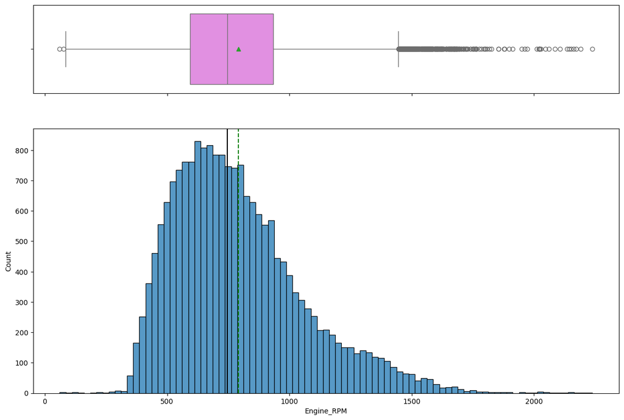

```python
histogram_boxplot(df, "Engine_RPM")
```

**Observation:**

- `Engine_RPM` shows natural operational variability.
- This variable is suitable for failure prediction.
- The distribution of engine RPM is right-skewed with a peak around 500-1000 rpm.
- There's a long tail with a few high rpm values, which could be instances when the engine is running at high speeds or outliers. -The RPM data has a few outliers on the high end, indicating moments where the engine is operating at very high speeds.

### Lub_Oil_Pressure Distribution

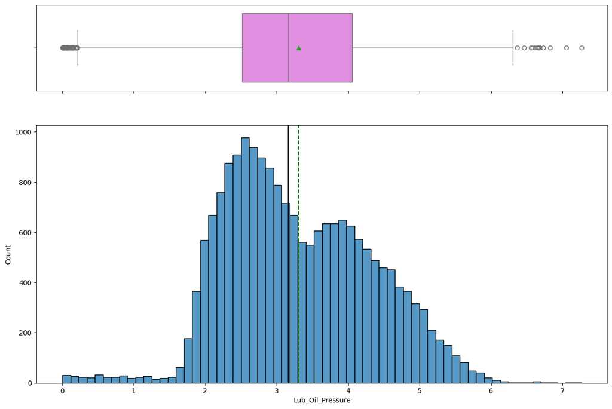

```python
histogram_boxplot(df, "Lub_Oil_Pressure")
```

**Observation:**

- `Lub_Oil_Pressure` shows natural operational variability.
- Extreme values may indicate abnormal engine behavior.
- This variable is suitable for failure prediction.
- Lub_Oil_Pressure to have a bimodal distribution, suggesting there are two common states of oil pressure that the engine operates under. -This distribution also shows a skew, with multiple outliers that are significantly higher than the main data cluster.

### Fuel_Pressure Distribution

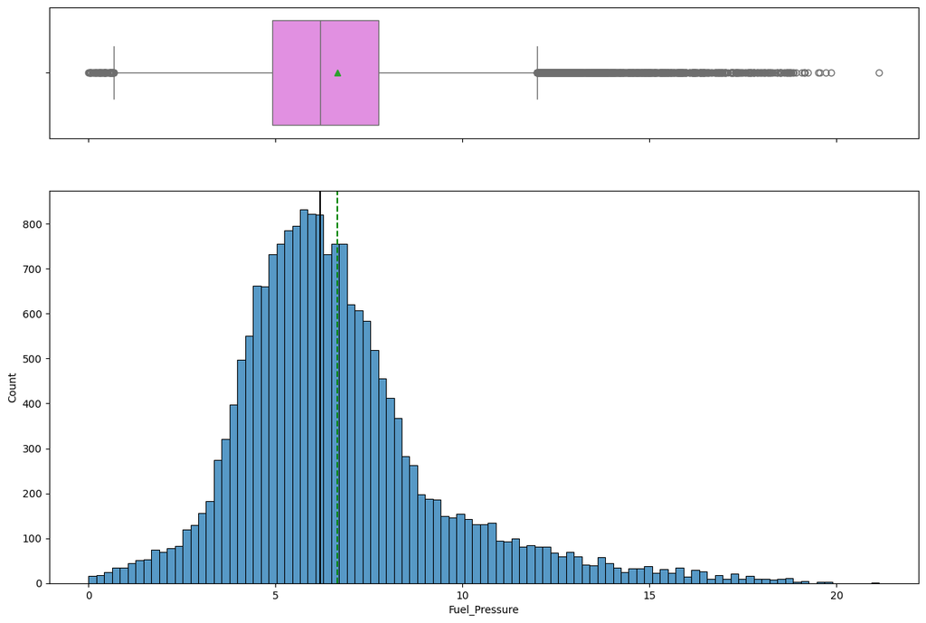

```python
histogram_boxplot(df, "Fuel_Pressure")
```

**Observation:**

- `Fuel_Pressure` shows natural operational variability.
- Fuel pressure shows a right-skewed distribution, with most data points clustered on the lower end and some potential outliers with very high fuel pressure readings.
- This variable is suitable for failure prediction.
- Similar to coolant pressure, fuel pressure also has a heavy right skew with several outliers.

### Coolant_Pressure Distribution

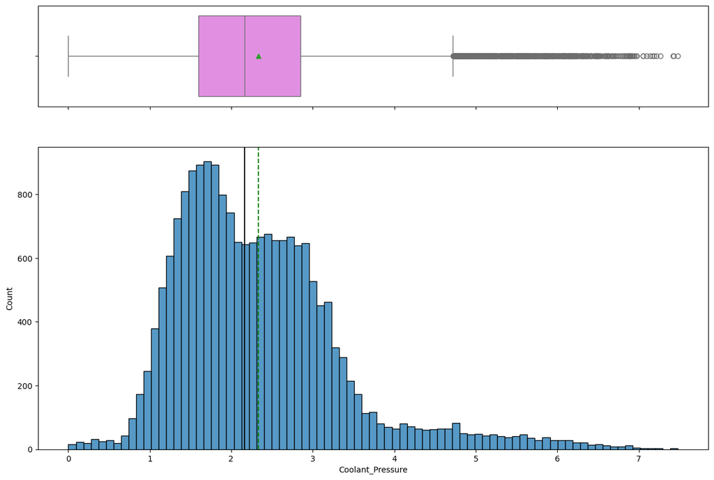

```python
histogram_boxplot(df, "Coolant_Pressure")
```

**Observation:**

- `Coolant_Pressure` shows natural operational variability.
- This variable is suitable for failure prediction.
- The distribution is somewhat skewed to the right, with most of the data falling below 2.5 units of pressure.
- Similar to coolant temperature, there's a long tail suggesting outliers or extreme values that may need further investigation.

### Lub_Oil_Temperature Distribution

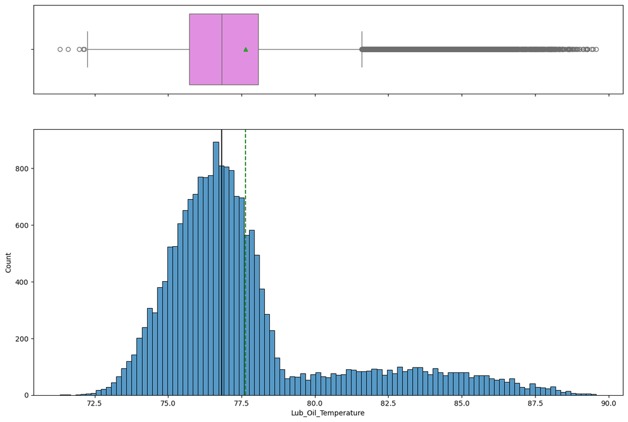

```python
histogram_boxplot(df, "Lub_Oil_Temperature")
```

### Coolant_Temperature Distribution

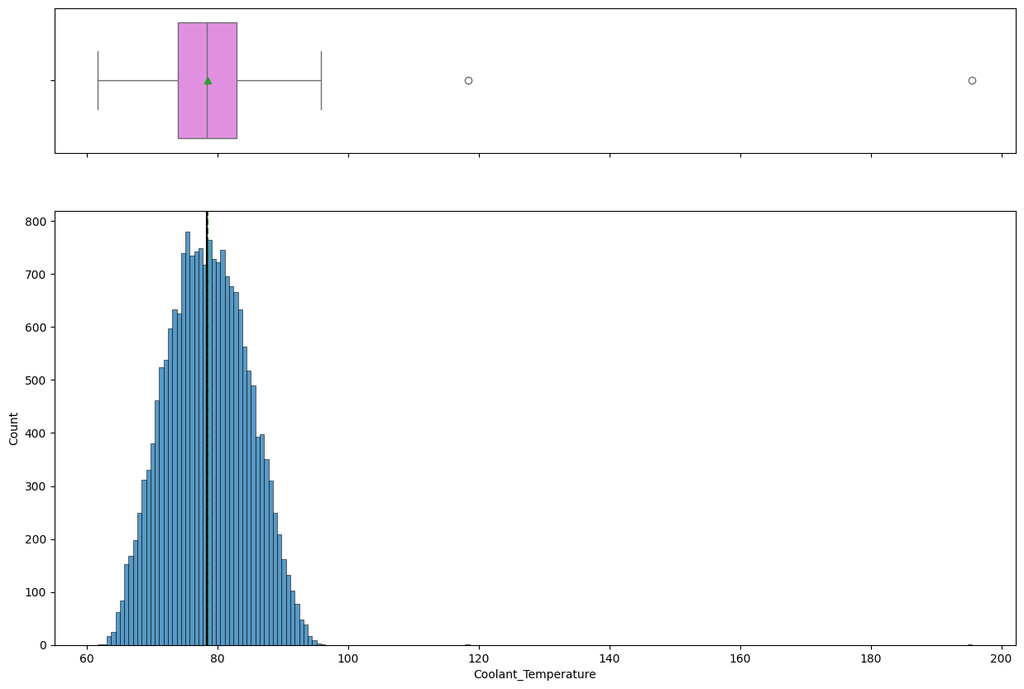

```python
histogram_boxplot(df, "Coolant_Temperature")
```

## 7.Correlation Analysis

```python
df.corr()['Engine_Condition'].sort_values(ascending=False)
```

|  | Engine_Condition |
| --- | --- |
| Engine_Condition | 1.000000 |
| Fuel_Pressure | 0.116259 |
| Lub_Oil_Pressure | 0.060904 |
| Coolant_Pressure | -0.024054 |
| Coolant_Temperature | -0.046326 |
| Lub_Oil_Temperature | -0.093635 |
| Engine_RPM | -0.268201 |

**dtype:** float64

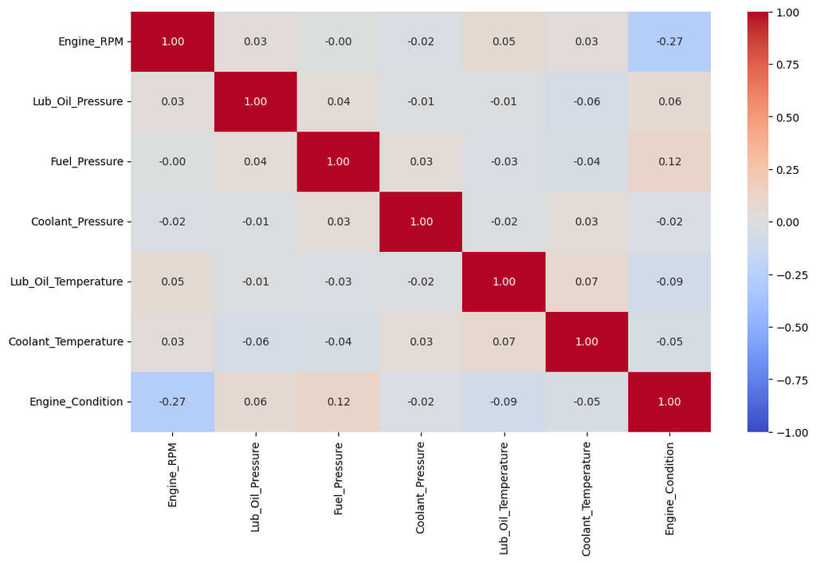

```python
# creating a list of numerical columns
num_cols = df.select_dtypes(include=np.number).columns.tolist()

plt.figure(figsize=(12, 7))
sns.heatmap(
    df[num_cols].corr(), annot=True, vmin=-1, vmax=1, fmt=".2f", cmap="coolwarm"
)
plt.show()
```

Based on the correlation matrix:

- it looks like there is a moderate negative correlation between the engine RPM and the engine condition, with a coefficient of -0.27. This suggests that as the engine RPM increases, the likelihood of a negative engine condition (presumably '0' which might indicate normal condition) increases slightly, or conversely, lower RPMs are more associated with a positive engine condition (presumably '1' which might indicate a fault). It's not a very strong correlation, but it is the most notable among the features.

Given these insights, it would be helpful to look at scatter plots to see if there are any non-linear patterns or clusters that indicate a relationship with the engine condition.

### 8. Scatter Plots

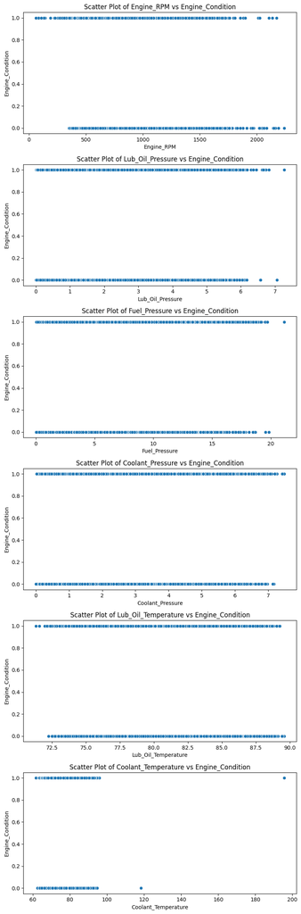

```python
# Plot scatter plots for each feature against engine condition
num_sensors = len(df.columns) - 1  # minus 1 to exclude the target variable
fig, axes = plt.subplots(nrows=num_sensors, ncols=1, figsize=(8, num_sensors*4))

# If only one feature is present, 'axes' will not be an array, so we wrap it into a list
if num_sensors == 1:
    axes = [axes]

for i, column in enumerate(df.columns[:-1]):  # exclude the target variable
    sns.scatterplot(data=df, x=column, y='Engine_Condition', ax=axes[i])
    axes[i].set_title(f'Scatter Plot of {column} vs Engine_Condition')

plt.tight_layout()
plt.show()
```

## Scaling and Normalization of the feature

```python
from sklearn.preprocessing import RobustScaler

# Assuming 'data' is our DataFrame and 'features' are our columns of interest
features = df.columns[:-1]  # Exclude the target variable 'Engine Condition'

# Initialize the RobustScaler
scaler = RobustScaler()

# Fit the scaler to the features and transform
data_scaled = scaler.fit_transform(df[features])

# Convert the array back to a DataFrame
data_scaled = pd.DataFrame(data_scaled, columns=features)

# Optionally, we can add the target variable back to the scaled DataFrame
data_scaled['Engine_Condition'] = df['Engine_Condition']

# Now 'data_scaled' is a DataFrame with the scaled features
```

```python
print(data_scaled.head())
```

```
   Engine_RPM  Lub_Oil_Pressure  Fuel_Pressure  Coolant_Pressure  \
0   -0.134897         -0.435055       1.976321          0.810733
1    0.381232         -0.143466       3.533182          0.238407
2   -0.662757         -0.130358       0.124263         -0.883178
3   -0.800587          0.355233       4.705814          1.250084
4   -0.372434          1.634204       3.372298         -0.091825

   Lub_Oil_Temperature  Coolant_Temperature  Engine_Condition
0             3.123507             0.364249                 1
1             0.351104             0.454442                 0
2             0.398566             0.144026                 1
3            -1.145689            -0.728608                 1
4             0.673419             0.959376                 0
```

## Define Target Variable and Splitting data

```python
# Define the target variable
target = 'Engine_Condition'

features = df.select_dtypes(include=np.number).columns.tolist()

print(target)
print(features)
```

```
Engine_Condition
['Engine_RPM', 'Lub_Oil_Pressure', 'Fuel_Pressure', 'Coolant_Pressure', 'Lub_Oil_Temperature', 'Coolant_Temperature', 'Engine_Condition']
```

## 9. Splitting Data into Training and Test Sets

```python
# Define X and y
X = data_scaled.drop('Engine_Condition', axis=1)
y = data_scaled['Engine_Condition']

# Split the data into training and testing sets
X_train, X_test, y_train, y_test = train_test_split(X, y, test_size=0.2, random_state=42, stratify=y)

print(f"Shape of X_train: {X_train.shape}")
print(f"Shape of X_test: {X_test.shape}")
print(f"Shape of y_train: {y_train.shape}")
print(f"Shape of y_test: {y_test.shape}")
```

```
Shape of X_train: (15628, 6)
Shape of X_test: (3907, 6)
Shape of y_train: (15628,)
Shape of y_test: (3907,)
```

```python
# Create a preprocessing pipeline for numerical features
numeric_features = X_train.select_dtypes(include=np.number).columns.tolist()

print(numeric_features)

preprocessor = make_column_transformer(
    (Pipeline([('num_imputer', SimpleImputer(strategy='median')),
               ('scaler', StandardScaler())]), numeric_features)
)
```

```
['Engine_RPM', 'Lub_Oil_Pressure', 'Fuel_Pressure', 'Coolant_Pressure', 'Lub_Oil_Temperature', 'Coolant_Temperature']
```

```python
import os

# Create a new directory named 'dataset' if it doesn't already exist
dataset_folder = 'dataset'
os.makedirs(dataset_folder, exist_ok=True)
print(f"Directory '{dataset_folder}' ensured to exist.")
```

```
Directory 'dataset' ensured to exist.
```

```python
X_train.to_csv(os.path.join(dataset_folder, 'X_train.csv'), index=False)
y_train.to_csv(os.path.join(dataset_folder, 'y_train.csv'), index=False)
X_test.to_csv(os.path.join(dataset_folder, 'X_test.csv'), index=False)
y_test.to_csv(os.path.join(dataset_folder, 'y_test.csv'), index=False)

print(f"Training and testing datasets saved to '{dataset_folder}' folder.")
```

```
Training and testing datasets saved to 'dataset' folder.
```

```python
from huggingface_hub import HfApi

# Initialize the Hugging Face API
api = HfApi()

# Define the Hugging Face dataset repository ID
repo_id = "VeerendraManikonda/predictive-maintenance-engine-health-dataset"

# Define the local folder containing the datasets
local_dataset_folder = 'dataset'

# Upload the 'dataset' folder to the Hugging Face dataset repository
api.upload_folder(
    folder_path=local_dataset_folder,  # Path to the local 'dataset' folder
    repo_id=repo_id,  # Hugging Face dataset repository ID
    repo_type="dataset",  # Specify the repository type as 'dataset'
    commit_message="Upload X_train, y_train, X_test, y_test CSV files"
)

print(f"Successfully uploaded '{local_dataset_folder}' folder to {repo_id}.")
```

```
No files have been modified since last commit. Skipping to prevent empty commit.
WARNING:huggingface_hub.hf_api:No files have been modified since last commit. Skipping to prevent empty commit.
```

```
Successfully uploaded 'dataset' folder to VeerendraManikonda/predictive-maintenance-engine-health-dataset.
```

## 10. Model Building

## Define functions for Classification Model Evaluation

```python
# Function to compute different metrics to check performance of a classification model
def model_performance_classification(model, predictors, target):
    """
    Function to compute different metrics to check classification model performance

    model: classifier
    predictors: independent variables
    target: dependent variable
    """

    # Predicting using the independent variables
    pred = model.predict(predictors)
    pred_proba = model.predict_proba(predictors)[:, 1]

    accuracy = accuracy_score(target, pred)  # to compute accuracy
    precision = precision_score(target, pred)  # to compute precision
    recall = recall_score(target, pred)  # to compute recall
    f1 = f1_score(target, pred)  # to compute F1-score
    roc_auc = metrics.roc_auc_score(target, pred_proba) # to compute ROC AUC

    # Creating a dataframe of metrics
    df_perf = pd.DataFrame(
        {
            "Accuracy": accuracy,
            "Precision": precision,
            "Recall": recall,
            "F1-Score": f1,
            "ROC AUC": roc_auc
        },
        index=[0],
    )

    return df_perf
```

### Logistic Regression - Model Training Pipeline

```python
from sklearn.linear_model import LogisticRegression

# Define base Logistic Regression model
log_reg_model = LogisticRegression(random_state=42)

# Create pipeline with preprocessing and Logistic Regression model
log_reg_pipeline = make_pipeline(preprocessor, log_reg_model)

# Train the model pipeline on the training data
log_reg_pipeline.fit(X_train, y_train)
```

```
Pipeline(steps=[('columntransformer',
                 ColumnTransformer(transformers=[('pipeline',
                                                  Pipeline(steps=[('num_imputer',
                                                                   SimpleImputer(strategy='median')),
                                                                  ('scaler',
                                                                   StandardScaler())]),
                                                  ['Engine_RPM',
                                                   'Lub_Oil_Pressure',
                                                   'Fuel_Pressure',
                                                   'Coolant_Pressure',
                                                   'Lub_Oil_Temperature',
                                                   'Coolant_Temperature'])])),
                ('logisticregression', LogisticRegression(random_state=42))])
```

#### Training Performance

```python
log_reg_train_perf = model_performance_classification(log_reg_pipeline, X_train, y_train)
print("Training performance \n")
log_reg_train_perf
```

```
Training performance
```

|  | Accuracy | Precision | Recall | F1-Score | ROC AUC |
| --- | --- | --- | --- | --- | --- |
| 0 | 0.661889 | 0.679723 | 0.877004 | 0.765863 | 0.689119 |

#### Testing Performance

```python
log_reg_test_perf = model_performance_classification(log_reg_pipeline, X_test, y_test)
print("Testing performance \n")
log_reg_test_perf
```

```
Testing performance
```

|  | Accuracy | Precision | Recall | F1-Score | ROC AUC |
| --- | --- | --- | --- | --- | --- |
| 0 | 0.661121 | 0.678695 | 0.878197 | 0.765664 | 0.69176 |

**Observations:**

- The Logistic Regression model shows consistent, moderate performance on both training and testing datasets, with similar accuracy, precision, recall, F1-score, and ROC AUC, indicating good generalization and no significant overfitting or underfitting

### Random Forest Classifier - Model Training Pipeline

```python
from sklearn.ensemble import RandomForestClassifier

# Define base Random Forest Classifier model
rf_classifier_model = RandomForestClassifier(random_state=42)

# Create pipeline with preprocessing and Random Forest Classifier model
rf_classifier_pipeline = make_pipeline(preprocessor, rf_classifier_model)

# Train the model pipeline on the training data
rf_classifier_pipeline.fit(X_train, y_train)
```

```
Pipeline(steps=[('columntransformer',
                 ColumnTransformer(transformers=[('pipeline',
                                                  Pipeline(steps=[('num_imputer',
                                                                   SimpleImputer(strategy='median')),
                                                                  ('scaler',
                                                                   StandardScaler())]),
                                                  ['Engine_RPM',
                                                   'Lub_Oil_Pressure',
                                                   'Fuel_Pressure',
                                                   'Coolant_Pressure',
                                                   'Lub_Oil_Temperature',
                                                   'Coolant_Temperature'])])),
                ('randomforestclassifier',
                 RandomForestClassifier(random_state=42))])
```

#### Training Performance (Random Forest Classifier)

```python
rf_classifier_train_perf = model_performance_classification(rf_classifier_pipeline, X_train, y_train)
print("Training performance \n")
rf_classifier_train_perf
```

```
Training performance
```

|  | Accuracy | Precision | Recall | F1-Score | ROC AUC |
| --- | --- | --- | --- | --- | --- |
| 0 | 1.0 | 1.0 | 1.0 | 1.0 | 1.0 |

#### Testing Performance (Random Forest Classifier)

```python
rf_classifier_test_perf = model_performance_classification(rf_classifier_pipeline, X_test, y_test)
print("Testing performance \n")
rf_classifier_test_perf
```

```
Testing performance
```

|  | Accuracy | Precision | Recall | F1-Score | ROC AUC |
| --- | --- | --- | --- | --- | --- |
| 0 | 0.648579 | 0.691362 | 0.799432 | 0.74148 | 0.678101 |

**Observations:**

- The Random Forest Classifier exhibits severe overfitting.
- On the training data, it achieves perfect scores across all metrics (Accuracy, Precision, Recall, F1-Score, and ROC AUC are all 1.0). However, its performance drops significantly on the testing data, with accuracy at 0.6486, precision at 0.6914, recall at 0.7994, F1-Score at 0.7415, and ROC AUC at 0.6781.
- This indicates that the model has learned the training data too well and is not generalizing effectively to unseen data.

### Random Forest Classifier - Hyperparameter Tuning

```python
# Choose the type of classifier.
rf_classifier_tuned = RandomForestClassifier(random_state=42)

# Create pipeline with preprocessing and Random Forest Classifier model
rf_classifier_pipeline_tuned = make_pipeline(preprocessor, rf_classifier_tuned)

# Grid of parameters to choose from
param_grid_rf_classifier = {
    'randomforestclassifier__n_estimators': [50, 100, 150],
    'randomforestclassifier__max_depth': [5, 10, 15],
    'randomforestclassifier__min_samples_leaf': [1, 2, 4],
    'randomforestclassifier__min_samples_split': [2, 5, 10]
}

# Type of scoring used to compare parameter combinations (using F1-score as it is good for imbalanced data)
scorer_rf_classifier = metrics.make_scorer(metrics.f1_score)

# Run the grid search
grid_obj_rf_classifier = GridSearchCV(rf_classifier_pipeline_tuned, param_grid_rf_classifier, scoring=scorer_rf_classifier, cv=5, n_jobs=-1)
grid_obj_rf_classifier = grid_obj_rf_classifier.fit(X_train, y_train)

# Set the classifier to the best combination of parameters
rf_classifier_tuned = grid_obj_rf_classifier.best_estimator_

# Fit the best algorithm to the data.
rf_classifier_tuned.fit(X_train, y_train)
```

```
Pipeline(steps=[('columntransformer',
                 ColumnTransformer(transformers=[('pipeline',
                                                  Pipeline(steps=[('num_imputer',
                                                                   SimpleImputer(strategy='median')),
                                                                  ('scaler',
                                                                   StandardScaler())]),
                                                  ['Engine_RPM',
                                                   'Lub_Oil_Pressure',
                                                   'Fuel_Pressure',
                                                   'Coolant_Pressure',
                                                   'Lub_Oil_Temperature',
                                                   'Coolant_Temperature'])])),
                ('randomforestclassifier',
                 RandomForestClassifier(max_depth=5, min_samples_leaf=2,
                                        min_samples_split=10,
                                        random_state=42))])
```

#### Training Performance (Tuned Random Forest Classifier)

```python
rf_classifier_tuned_train_perf = model_performance_classification(rf_classifier_tuned, X_train, y_train)
print("Training performance \n")
rf_classifier_tuned_train_perf
```

```
Training performance
```

|  | Accuracy | Precision | Recall | F1-Score | ROC AUC |
| --- | --- | --- | --- | --- | --- |
| 0 | 0.682301 | 0.687822 | 0.908464 | 0.782894 | 0.723233 |

#### Testing Performance (Tuned Random Forest Classifier)

```python
rf_classifier_tuned_test_perf = model_performance_classification(rf_classifier_tuned, X_test, y_test)
print("Testing performance \n")
rf_classifier_tuned_test_perf
```

```
Testing performance
```

|  | Accuracy | Precision | Recall | F1-Score | ROC AUC |
| --- | --- | --- | --- | --- | --- |
| 0 | 0.659073 | 0.672251 | 0.896062 | 0.768187 | 0.698913 |

**Observations:**

- After hyperparameter tuning, the Random Forest Classifier shows a significant improvement in generalization.
- While there's still a slight difference between training and testing performance, the model is no longer severely overfitting.
- The test performance metrics are much closer to the training performance, indicating a more robust model that can predict engine conditions effectively on unseen data.
- The high recall suggests it's good at identifying faulty engines, which is important for predictive maintenance.

### XGBoost Classifier - Model Training Pipeline

```python
from xgboost import XGBClassifier

# Define base XGBoost Classifier model
xgb_classifier_model = XGBClassifier(random_state=42, use_label_encoder=False, eval_metric='logloss')

# Create pipeline with preprocessing and XGBoost Classifier model
xgb_classifier_pipeline = make_pipeline(preprocessor, xgb_classifier_model)

# Train the model pipeline on the training data
xgb_classifier_pipeline.fit(X_train, y_train)
```

```
Pipeline(steps=[('columntransformer',
                 ColumnTransformer(transformers=[('pipeline',
                                                  Pipeline(steps=[('num_imputer',
                                                                   SimpleImputer(strategy='median')),
                                                                  ('scaler',
                                                                   StandardScaler())]),
                                                  ['Engine_RPM',
                                                   'Lub_Oil_Pressure',
                                                   'Fuel_Pressure',
                                                   'Coolant_Pressure',
                                                   'Lub_Oil_Temperature',
                                                   'Coolant_Temperature'])])),
                ('xgbclassifier',
                 XGBClassifier(base_score=None, booster=No...
                               feature_types=None, feature_weights=None,
                               gamma=None, grow_policy=None,
                               importance_type=None,
                               interaction_constraints=None, learning_rate=None,
                               max_bin=None, max_cat_threshold=None,
                               max_cat_to_onehot=None, max_delta_step=None,
                               max_depth=None, max_leaves=None,
                               min_child_weight=None, missing=nan,
                               monotone_constraints=None, multi_strategy=None,
                               n_estimators=None, n_jobs=None,
                               num_parallel_tree=None, ...))])
```

#### Training Performance (XGBoost Classifier)

```python
xgb_classifier_train_perf = model_performance_classification(xgb_classifier_pipeline, X_train, y_train)
print("Training performance \n")
xgb_classifier_train_perf
```

```
Training performance
```

|  | Accuracy | Precision | Recall | F1-Score | ROC AUC |
| --- | --- | --- | --- | --- | --- |
| 0 | 0.856732 | 0.848003 | 0.941547 | 0.89233 | 0.936109 |

#### Testing Performance (XGBoost Classifier)

```python
xgb_classifier_test_perf = model_performance_classification(xgb_classifier_pipeline, X_test, y_test)
print("Testing performance \n")
xgb_classifier_test_perf
```

```
Testing performance
```

|  | Accuracy | Precision | Recall | F1-Score | ROC AUC |
| --- | --- | --- | --- | --- | --- |
| 0 | 0.643716 | 0.688623 | 0.793747 | 0.737458 | 0.66552 |

**Observations:**

- The XGBoost Classifier shows a strong performance on the training data, but its performance significantly drops on the testing data.
- This significant drop in performance indicates that the model is overfitting to the training data and is not generalizing effectively to unseen data.
- Further hyperparameter tuning would be beneficial for this model as well.

### XGBoost Classifier - Hyperparameter Tuning

```python
# Choose the type of classifier.
xgb_classifier_tuned = XGBClassifier(random_state=42, use_label_encoder=False, eval_metric='logloss')

# Create pipeline with preprocessing and XGBoost Classifier model
xgb_classifier_pipeline_tuned = make_pipeline(preprocessor, xgb_classifier_tuned)

# Grid of parameters to choose from
param_grid_xgb_classifier = {
    'xgbclassifier__n_estimators': [50, 100, 150],
    'xgbclassifier__max_depth': [3, 5, 7],
    'xgbclassifier__learning_rate': [0.01, 0.05, 0.1],
    'xgbclassifier__subsample': [0.6, 0.8, 1.0],
    'xgbclassifier__colsample_bytree': [0.6, 0.8, 1.0]
}

# Type of scoring used to compare parameter combinations (using F1-score as it is good for imbalanced data)
scorer_xgb_classifier = metrics.make_scorer(metrics.f1_score)

# Run the grid search
grid_obj_xgb_classifier = GridSearchCV(xgb_classifier_pipeline_tuned, param_grid_xgb_classifier, scoring=scorer_xgb_classifier, cv=5, n_jobs=-1)
grid_obj_xgb_classifier = grid_obj_xgb_classifier.fit(X_train, y_train)

# Set the classifier to the best combination of parameters
xgb_classifier_tuned = grid_obj_xgb_classifier.best_estimator_

# Fit the best algorithm to the data.
xgb_classifier_tuned.fit(X_train, y_train)
```

```
Pipeline(steps=[('columntransformer',
                 ColumnTransformer(transformers=[('pipeline',
                                                  Pipeline(steps=[('num_imputer',
                                                                   SimpleImputer(strategy='median')),
                                                                  ('scaler',
                                                                   StandardScaler())]),
                                                  ['Engine_RPM',
                                                   'Lub_Oil_Pressure',
                                                   'Fuel_Pressure',
                                                   'Coolant_Pressure',
                                                   'Lub_Oil_Temperature',
                                                   'Coolant_Temperature'])])),
                ('xgbclassifier',
                 XGBClassifier(base_score=None, booster=No...
                               feature_types=None, feature_weights=None,
                               gamma=None, grow_policy=None,
                               importance_type=None,
                               interaction_constraints=None, learning_rate=0.01,
                               max_bin=None, max_cat_threshold=None,
                               max_cat_to_onehot=None, max_delta_step=None,
                               max_depth=7, max_leaves=None,
                               min_child_weight=None, missing=nan,
                               monotone_constraints=None, multi_strategy=None,
                               n_estimators=100, n_jobs=None,
                               num_parallel_tree=None, ...))])
```

#### Training Performance (Tuned XGBoost Classifier)

```python
xgb_classifier_tuned_train_perf = model_performance_classification(xgb_classifier_tuned, X_train, y_train)
print("Training performance \n")
xgb_classifier_tuned_train_perf
```

```
Training performance
```

|  | Accuracy | Precision | Recall | F1-Score | ROC AUC |
| --- | --- | --- | --- | --- | --- |
| 0 | 0.674942 | 0.663605 | 0.982545 | 0.792178 | 0.777315 |

#### Testing Performance (Tuned XGBoost Classifier)

```python
xgb_classifier_tuned_test_perf = model_performance_classification(xgb_classifier_tuned, X_test, y_test)
print("Testing performance \n")
xgb_classifier_tuned_test_perf
```

```
Testing performance
```

|  | Accuracy | Precision | Recall | F1-Score | ROC AUC |
| --- | --- | --- | --- | --- | --- |
| 0 | 0.650115 | 0.648671 | 0.970767 | 0.777687 | 0.698736 |

## 11. Model Performance Comparison and Final Model Selection

```python
# Training performance comparison for classification models
models_train_comp_df_clf = pd.concat(
    [log_reg_train_perf.T,
     rf_classifier_train_perf.T,
     rf_classifier_tuned_train_perf.T,
     xgb_classifier_train_perf.T,
     xgb_classifier_tuned_train_perf.T],
    axis=1
)

models_train_comp_df_clf.columns = [
    "Logistic Regression",
    "Random Forest Classifier (Untuned)",
    "Random Forest Classifier (Tuned)",
    "XGBoost Classifier (Untuned)",
    "XGBoost Classifier (Tuned)"
]

print("Training performance comparison for Classification Models:")
display(models_train_comp_df_clf)
```

```
Training performance comparison for Classification Models:
```

|  | Logistic Regression | Random Forest Classifier (Untuned) | Random Forest Classifier (Tuned) | XGBoost Classifier (Untuned) | XGBoost Classifier (Tuned) |
| --- | --- | --- | --- | --- | --- |
| Accuracy | 0.661889 | 1.0 | 0.682301 | 0.856732 | 0.674942 |
| Precision | 0.679723 | 1.0 | 0.687822 | 0.848003 | 0.663605 |
| Recall | 0.877004 | 1.0 | 0.908464 | 0.941547 | 0.982545 |
| F1-Score | 0.765863 | 1.0 | 0.782894 | 0.892330 | 0.792178 |
| ROC AUC | 0.689119 | 1.0 | 0.723233 | 0.936109 | 0.777315 |

```python
# Testing performance comparison for classification models
models_test_comp_df_clf = pd.concat(
    [log_reg_test_perf.T,
     rf_classifier_test_perf.T,
     rf_classifier_tuned_test_perf.T,
     xgb_classifier_test_perf.T,
     xgb_classifier_tuned_test_perf.T],
    axis=1
)

models_test_comp_df_clf.columns = [
    "Logistic Regression",
    "Random Forest Classifier (Untuned)",
    "Random Forest Classifier (Tuned)",
    "XGBoost Classifier (Untuned)",
    "XGBoost Classifier (Tuned)"
]

print("Testing performance comparison for Classification Models:")
display(models_test_comp_df_clf)
```

```
Testing performance comparison for Classification Models:
```

|  | Logistic Regression | Random Forest Classifier (Untuned) | Random Forest Classifier (Tuned) | XGBoost Classifier (Untuned) | XGBoost Classifier (Tuned) |
| --- | --- | --- | --- | --- | --- |
| Accuracy | 0.661121 | 0.648579 | 0.659073 | 0.643716 | 0.650115 |
| Precision | 0.678695 | 0.691362 | 0.672251 | 0.688623 | 0.648671 |
| Recall | 0.878197 | 0.799432 | 0.896062 | 0.793747 | 0.970767 |
| F1-Score | 0.765664 | 0.741480 | 0.768187 | 0.737458 | 0.777687 |
| ROC AUC | 0.691760 | 0.678101 | 0.698913 | 0.665520 | 0.698736 |

```python
(models_train_comp_df_clf - models_test_comp_df_clf).iloc[2]
```

|  | Recall |
| --- | --- |
| Logistic Regression | -0.001193 |
| Random Forest Classifier (Untuned) | 0.200568 |
| Random Forest Classifier (Tuned) | 0.012402 |
| XGBoost Classifier (Untuned) | 0.147799 |
| XGBoost Classifier (Tuned) | 0.011778 |

**dtype:** float64

**Final Model Selection :**

## 12. Model Serialization

Note: Based on the model comparison, the XGB-tuned model demonstrated the best performance on the testing data. Therefore, we will serialize this model for deployment.

```python
# Create a folder for storing the files needed for web app deployment
os.makedirs("deployment_files", exist_ok=True)
```

```python
# Define the file path to save (serialize) the trained model along with the data preprocessing steps
saved_model_path = "deployment_files/Predictive_Maintenance_XGB_Tuned_model_v1_0.joblib"
```

```python
# Save the best trained model pipeline using joblib
joblib.dump(xgb_classifier_tuned, saved_model_path)

print(f"Model saved successfully at {saved_model_path}")
```

```
Model saved successfully at deployment_files/Predictive_Maintenance_XGB_Tuned_model_v1_0.joblib
```

## 13. Load the Serialized Model

```python
# Load the saved model pipeline from the file
saved_model = joblib.load("deployment_files/Predictive_Maintenance_XGB_Tuned_model_v1_0.joblib")

# Confirm the model is loaded
print("Model loaded successfully.")
```

```
Model loaded successfully.
```

```python
saved_model
```

```
Pipeline(steps=[('columntransformer',
                 ColumnTransformer(transformers=[('pipeline',
                                                  Pipeline(steps=[('num_imputer',
                                                                   SimpleImputer(strategy='median')),
                                                                  ('scaler',
                                                                   StandardScaler())]),
                                                  ['Engine_RPM',
                                                   'Lub_Oil_Pressure',
                                                   'Fuel_Pressure',
                                                   'Coolant_Pressure',
                                                   'Lub_Oil_Temperature',
                                                   'Coolant_Temperature'])])),
                ('xgbclassifier',
                 XGBClassifier(base_score=None, booster=No...
                               feature_types=None, feature_weights=None,
                               gamma=None, grow_policy=None,
                               importance_type=None,
                               interaction_constraints=None, learning_rate=0.01,
                               max_bin=None, max_cat_threshold=None,
                               max_cat_to_onehot=None, max_delta_step=None,
                               max_depth=7, max_leaves=None,
                               min_child_weight=None, missing=nan,
                               monotone_constraints=None, multi_strategy=None,
                               n_estimators=100, n_jobs=None,
                               num_parallel_tree=None, ...))])
```

Let's try making predictions on the test set using the deserialized model.

```python
saved_model.predict(X_test)
```

```
array([1, 1, 1, ..., 1, 1, 1])
```

- As we can see, the model can be directly used for making predictions without any retraining.

```python
import os

# Create a folder to upload your trained serialized model into it
os.makedirs("backend_files", exist_ok=True)
```

```python
# Define the file path to load the uploaded serialized model
model_path = "backend_files/Predictive_Maintenance_XGB_Tuned_model_v1_0.joblib"
```

```python
import shutil

# Define source and destination paths
source_path = saved_model_path  # Path where the model was saved
destination_path = model_path  # Path in the backend_files folder

# Copy the file
shutil.copyfile(source_path, destination_path)

print(f"Model copied from {source_path} to {destination_path}")
```

```
Model copied from deployment_files/Predictive_Maintenance_XGB_Tuned_model_v1_0.joblib to backend_files/Predictive_Maintenance_XGB_Tuned_model_v1_0.joblib
```

```python
import joblib

# Load the saved model pipeline from the file
saved_model = joblib.load(model_path)

# Confirm the model is loaded
print("Model loaded successfully.")
```

```
Model loaded successfully.
```

```python
saved_model
```

```
Pipeline(steps=[('columntransformer',
                 ColumnTransformer(transformers=[('pipeline',
                                                  Pipeline(steps=[('num_imputer',
                                                                   SimpleImputer(strategy='median')),
                                                                  ('scaler',
                                                                   StandardScaler())]),
                                                  ['Engine_RPM',
                                                   'Lub_Oil_Pressure',
                                                   'Fuel_Pressure',
                                                   'Coolant_Pressure',
                                                   'Lub_Oil_Temperature',
                                                   'Coolant_Temperature'])])),
                ('xgbclassifier',
                 XGBClassifier(base_score=None, booster=No...
                               feature_types=None, feature_weights=None,
                               gamma=None, grow_policy=None,
                               importance_type=None,
                               interaction_constraints=None, learning_rate=0.01,
                               max_bin=None, max_cat_threshold=None,
                               max_cat_to_onehot=None, max_delta_step=None,
                               max_depth=7, max_leaves=None,
                               min_child_weight=None, missing=nan,
                               monotone_constraints=None, multi_strategy=None,
                               n_estimators=100, n_jobs=None,
                               num_parallel_tree=None, ...))])
```

```python
%%writefile backend_files/app.py
# Import necessary libraries
import numpy as np
import joblib  # For loading the serialized model
import pandas as pd  # For data manipulation
from flask import Flask, request, jsonify  # For creating the Flask API
import os # For accessing environment variables if needed
import logging # For logging

# Configure logging
logging.basicConfig(level=logging.INFO, format='%(asctime)s - %(levelname)s - %(message)s')

# Initialize the Flask application
predictive_maintenance_api = Flask("Predictive Maintenance API")

# Define the model path
# Use the correct path as defined in the notebook
#MODEL_PATH = "backend_files/Predictive_Maintenance_XGB_Tuned_model_v1_0.joblib"
MODEL_PATH = "Predictive_Maintenance_XGB_Tuned_model_v1_0.joblib" # Corrected path

# Load the trained machine learning model
model = None
try:
    model = joblib.load(MODEL_PATH)
    logging.info(f"Model loaded successfully from {MODEL_PATH}")
except Exception as e:
    logging.error(f"Error loading model: {e}")

# Define a route for the home page (GET request)
@predictive_maintenance_api.get('/')
def home():
    """
    This function handles GET requests to the root URL ('/') of the API.
    It returns a simple welcome message.
    """
    logging.info("Home page accessed.")
    return "Welcome to the Predictive Maintenance API for Engine Health!"

# Define an endpoint for engine condition prediction (POST request)
@predictive_maintenance_api.post('/v1/engine_condition_prediction')
def predict_engine_condition():
    """
    This function handles POST requests to the '/v1/engine_condition_prediction' endpoint.
    It expects a JSON payload containing engine sensor data and returns
    the predicted engine condition (0 for Normal, 1 for Faulty) as a JSON response.
    """
    logging.info("Prediction request received.")
    if model is None:
        logging.error("Model not loaded when prediction request came. Returning 500.")
        return jsonify({"error": "Model not loaded. Please check server logs."}), 500

    # Get the JSON data from the request body
    engine_data = request.get_json()
    logging.info(f"Received engine data: {engine_data}")

    # Extract relevant features from the JSON data
    # Features: 'Engine_RPM', 'Lub_Oil_Pressure', 'Fuel_Pressure', 'Coolant_Pressure', 'Lub_Oil_Temperature', 'Coolant_Temperature'
    try:
        sample_data = {
            'Engine_RPM': [engine_data['Engine_RPM']],
            'Lub_Oil_Pressure': [engine_data['Lub_Oil_Pressure']],
            'Fuel_Pressure': [engine_data['Fuel_Pressure']],
            'Coolant_Pressure': [engine_data['Coolant_Pressure']],
            'Lub_Oil_Temperature': [engine_data['Lub_Oil_Temperature']],
            'Coolant_Temperature': [engine_data['Coolant_Temperature']]
        }
        logging.debug(f"Extracted sample data: {sample_data}")
    except KeyError as e:
        logging.error(f"Missing data for feature: {e}. Returning 400.")
        return jsonify({"error": f"Missing data for feature: {e}. Please provide all required sensor readings."}), 400
    except Exception as e:
        logging.error(f"Unexpected error during data extraction: {e}. Returning 400.")
        return jsonify({"error": f"An unexpected error occurred during data processing: {e}"}), 400


    # Convert the extracted data into a Pandas DataFrame
    # Ensure the order of columns matches the training data
    input_df = pd.DataFrame(sample_data)

    # Make prediction
    try:
        prediction_proba = model.predict_proba(input_df)
        predicted_class = model.predict(input_df)[0]
        logging.info(f"Prediction made: class={predicted_class}, probabilities={prediction_proba}")
    except Exception as e:
        logging.error(f"Error during model prediction: {e}. Returning 500.")
        return jsonify({"error": f"Error during model prediction: {e}"}), 500

    # Map the predicted class to a readable string
    condition_map = {0: "Normal", 1: "Faulty"}
    predicted_condition_str = condition_map.get(predicted_class, "Unknown")

    # Return the prediction as a JSON response
    return jsonify({
        "predicted_engine_condition_class": int(predicted_class), # Ensure it's a standard Python int
        "predicted_engine_condition_label": predicted_condition_str,
        "probability_normal": round(float(prediction_proba[0][0]), 4),
        "probability_faulty": round(float(prediction_proba[0][1]), 4)
    })

# To run the Flask app (for local testing)
if __name__ == '__main__':
    # You might want to get the port from an environment variable for deployment
    port = int(os.environ.get('PORT', 5000))
    predictive_maintenance_api.run(host='0.0.0.0', port=port, debug=True)
```

```
Overwriting backend_files/app.py
```

## Setting up a Hugging Face Docker Space for the Backend

```python
# Import the login function from the huggingface_hub library
from huggingface_hub import login

# Login to your Hugging Face account using your access token
# Replace "YOUR_HUGGINGFACE_TOKEN" with your actual token
login(token="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")

# Import the create_repo function from the huggingface_hub library
from huggingface_hub import create_repo
```

```python
# Try to create the repository for the Hugging Face Space
try:
    create_repo("PredictiveMaintenanceBackend",  # One can replace "Backend_Docker_space" with the desired space name
        repo_type="space",  # Specify the repository type as "space"
        space_sdk="docker",  # Specify the space SDK as "docker" to create a Docker space
        private=False  # Set to True if you want the space to be private
    )
except Exception as e:
    # Handle potential errors during repository creation
    if "RepositoryAlreadyExistsError" in str(e):
        print("Repository already exists. Skipping creation.")
    else:
        print(f"Error creating repository: {e}")
```

```
Error creating repository: 409 Client Error: Conflict for url: https://huggingface.co/api/repos/create (Request ID: Root=1-6974d5d3-36f743e55dc20a956018a18b;ea11188a-b343-4d43-a4f5-05d6139cbcf3)

You already created this space repo: VeerendraManikonda/PredictiveMaintenanceBackend
```

## Dependencies File

```python
%%writefile backend_files/requirements.txt
pandas==2.2.2
numpy==2.0.2
scikit-learn==1.6.1
xgboost==2.1.4
joblib==1.4.2
Werkzeug==2.2.2
flask==2.2.2
gunicorn==20.1.0
requests==2.28.1
uvicorn[standard]
```

```
Overwriting backend_files/requirements.txt
```

## Dockerfile

```python
%%writefile backend_files/Dockerfile
FROM python:3.10-slim

# Set the working directory inside the container
WORKDIR /app

# Copy all files from the current directory to the container's working directory
COPY . .

# Install dependencies from the requirements file without using cache to reduce image size
RUN pip install --no-cache-dir --upgrade -r requirements.txt

# Define the command to start the application using Gunicorn with 4 worker processes
# - `-w 4`: Uses 4 worker processes for handling requests
# - `-b 0.0.0.0:7860`: Binds the server to port 7860 on all network interfaces
# - `app:app`: Runs the Flask app (assuming `app.py` contains the Flask instance named `app`)
CMD ["gunicorn", "-w", "4", "-b", "0.0.0.0:7860", "app:predictive_maintenance_api"]
```

```
Overwriting backend_files/Dockerfile
```

## Uploading Files to Hugging Face Space (Docker Space)

```python
# for hugging face space authentication to upload files
from huggingface_hub import HfApi

repo_id = "VeerendraManikonda/PredictiveMaintenanceBackend"  # Your Hugging Face space id

# Initialize the API
api = HfApi()

# Upload Streamlit app files stored in the folder called deployment_files
api.upload_folder(
    folder_path="/content/backend_files",  # Local folder path
    repo_id=repo_id,  # Hugging face space id
    repo_type="space",  # Hugging face repo type "space"
)
```

```
No files have been modified since last commit. Skipping to prevent empty commit.
WARNING:huggingface_hub.hf_api:No files have been modified since last commit. Skipping to prevent empty commit.
```

```
CommitInfo(commit_url='https://huggingface.co/spaces/VeerendraManikonda/PredictiveMaintenanceBackend/commit/a2b76892e3a55f40694e1d5cb1633c917ff019cd', commit_message='Upload folder using huggingface_hub', commit_description='', oid='a2b76892e3a55f40694e1d5cb1633c917ff019cd', pr_url=None, repo_url=Re…
```

```python
import sklearn
print(f"Scikit-learn version in Colab: {sklearn.__version__}")
```

```
Scikit-learn version in Colab: 1.6.1
```

# **Deployment - Frontend**

## Points to note before executing the below cells

- Create a Streamlit space on Hugging Face by following the instructions provided on the content page titled **`Creating Spaces and Adding Secrets in Hugging Face`**

## Streamlit for Interactive UI

```python
# Create a folder for storing the files needed for frontend UI deployment
os.makedirs("frontend_files", exist_ok=True)
```

```python
%%writefile frontend_files/app.py
import streamlit as st
import requests

# --- Streamlit App Configuration ---
st.set_page_config(
    page_title="Predictive Maintenance for Engine Health",
    page_icon="⚙️",
    layout="centered",
    initial_sidebar_state="expanded",
)

st.title("⚙️ Predictive Maintenance for Engine Health")
st.markdown("### Predict if an engine is Normal or Faulty based on sensor readings")

# --- Input Fields for Sensor Data ---
st.subheader("Engine Sensor Readings")

# Using st.number_input for numerical inputs with appropriate ranges and step
engine_rpm = st.number_input(
    "Engine RPM", min_value=0.0, max_value=3000.0, value=700.0, step=10.0,
    help="Revolutions per minute of the engine (RPM)"
)
lub_oil_pressure = st.number_input(
    "Lub Oil Pressure (bar/kPa)", min_value=0.0, max_value=10.0, value=2.5, step=0.1,
    help="Pressure of the lubricating oil"
)
fuel_pressure = st.number_input(
    "Fuel Pressure (bar/kPa)", min_value=0.0, max_value=30.0, value=12.0, step=0.1,
    help="Pressure at which fuel is supplied to the engine"
)
coolant_pressure = st.number_input(
    "Coolant Pressure (bar/kPa)", min_value=0.0, max_value=10.0, value=3.0, step=0.1,
    help="Pressure of the engine coolant"
)
lub_oil_temperature = st.number_input(
    "Lub Oil Temperature (°C)", min_value=0.0, max_value=150.0, value=85.0, step=0.5,
    help="Temperature of the lubricating oil"
)
coolant_temperature = st.number_input(
    "Coolant Temperature (°C)", min_value=0.0, max_value=150.0, value=80.0, step=0.5,
    help="Temperature of the engine coolant"
)

# --- Prediction Button and Logic ---

# Replace with the actual URL of your deployed backend API
# For local testing, it might be something like "http://localhost:5000"
# For Hugging Face Spaces, it will be the URL of your Docker Space
BACKEND_API_URL = "https://veerendramanikonda-predictivemaintenancebackend.hf.space/v1/engine_condition_prediction"

if st.button("Predict Engine Condition", type="primary"):
    # Prepare the data payload for the API request
    engine_data = {
        "Engine_RPM": engine_rpm,
        "Lub_Oil_Pressure": lub_oil_pressure,
        "Fuel_Pressure": fuel_pressure,
        "Coolant_Pressure": coolant_pressure,
        "Lub_Oil_Temperature": lub_oil_temperature,
        "Coolant_Temperature": coolant_temperature
    }

    try:
        # Make the POST request to the backend API
        response = requests.post(BACKEND_API_URL, json=engine_data)
        response.raise_for_status()  # Raise an exception for HTTP errors (4xx or 5xx)
        prediction = response.json()

        st.subheader("Prediction Results:")
        predicted_label = prediction['predicted_engine_condition_label']
        probability_faulty = prediction['probability_faulty']
        probability_normal = prediction['probability_normal']

        if predicted_label == "Faulty":
            st.error(f"The engine is predicted to be: **{predicted_label}**")
            st.write(f"Probability of Faulty: {probability_faulty:.2f}")
            st.write(f"Probability of Normal: {probability_normal:.2f}")
            st.warning("Immediate maintenance recommended!")
        else:
            st.success(f"The engine is predicted to be: **{predicted_label}**")
            st.write(f"Probability of Normal: {probability_normal:.2f}")
            st.write(f"Probability of Faulty: {probability_faulty:.2f}")
            st.info("Engine is operating normally.")

    except requests.exceptions.ConnectionError:
        st.error("Connection Error: Could not connect to the backend API. Please ensure the backend is running and the URL is correct.")
    except requests.exceptions.Timeout:
        st.error("Timeout Error: The request to the backend API timed out.")
    except requests.exceptions.RequestException as e:
        st.error(f"An error occurred during the API request: {e}")
    except Exception as e:
        st.error(f"An unexpected error occurred: {e}")
```

```
Overwriting frontend_files/app.py
```

## Dependencies File

```python
%%writefile frontend_files/requirements.txt
pandas==2.2.2
requests==2.28.1
streamlit==1.43.2
```

```
Writing frontend_files/requirements.txt
```

## DockerFile

```python
%%writefile frontend_files/Dockerfile
# Use a minimal base image with Python 3.9 installed
FROM python:3.9-slim

# Set the working directory inside the container to /app
WORKDIR /app

# Copy all files from the current directory on the host to the container's /app directory
COPY . .

# Install Python dependencies listed in requirements.txt
RUN pip3 install -r requirements.txt

# Define the command to run the Streamlit app on port 8501 and make it accessible externally
CMD ["streamlit", "run", "app.py", "--server.port=8501", "--server.address=0.0.0.0", "--server.enableXsrfProtection=false"]

# NOTE: Disable XSRF protection for easier external access in order to make batch predictions
```

```
Overwriting frontend_files/Dockerfile
```

## Uploading Files to Hugging Face Space (Streamlit Space)

```python
# Try to create the repository for the Hugging Face Space
from huggingface_hub import create_repo

# Try to create the repository for the Hugging Face Space

create_repo("PredictiveMaintenanceFrontend",  # One can replace "Backend_Docker_space" with the desired space name
    repo_type="space",  # Specify the repository type as "space"
    space_sdk="docker",  # Specify the space SDK as "docker" to create a Docker space
    private=False  # Set to True if you want the space to be private
)
```

[output not shown]

```python
# for hugging face space authentication to upload files
from huggingface_hub import HfApi

repo_id = "VeerendraManikonda/PredictiveMaintenanceFrontend"  # Your Hugging Face space id

# Initialize the API
api = HfApi()

# Upload Streamlit app files stored in the folder called deployment_files
api.upload_folder(
    folder_path="/content/frontend_files",  # Local folder path
    repo_id=repo_id,  # Hugging face space id
    repo_type="space",  # Hugging face repo type "space"
)
```

```
CommitInfo(commit_url='https://huggingface.co/spaces/VeerendraManikonda/PredictiveMaintenanceFrontend/commit/77055004369d2da48e2788b45da6138245f8c03f', commit_message='Upload folder using huggingface_hub', commit_description='', oid='77055004369d2da48e2788b45da6138245f8c03f', pr_url=None, repo_url=R…
```

# **Actionable Insights and Business Recommendations**

# **Actionable Insights and Business Recommendations**

## Business Recommendations:

1. **Implement the Tuned XGBoost Model:** Deploy the trained and serialized Tuned XGBoost Classifier as the core of a predictive maintenance system. Its high recall will ensure that a significant majority of potential engine failures are identified proactively.
2. **Real-time Monitoring and Alert System:** Integrate the model with real-time sensor data streams from engines. Develop an alert system that triggers notifications to maintenance teams when the model predicts a 'Faulty' condition, allowing for immediate inspection and intervention.
3. **Prioritize Maintenance based on Probability:** While the model provides a binary prediction, the probability scores for 'Faulty' conditions can be used to prioritize maintenance. Engines with a high probability of being faulty should be addressed more urgently.
4. **Regular Model Retraining and Monitoring:** Engine operating conditions, wear patterns, and sensor behaviors can change over time. Establish a schedule for regular retraining of the model with new data to maintain its accuracy and relevance. Continuously monitor model performance in production to detect any drift.
5. **Investigate False Positives:** While recall is prioritized, a high number of false positives can lead to unnecessary maintenance costs. Analyze false positives to understand their patterns and potentially refine features or model thresholds to balance recall with operational efficiency.
6. **Data Quality Assurance:** Maintain stringent data quality controls for sensor readings. Inaccurate or noisy data will directly impact the model's performance. Implement data validation checks at the point of data ingestion.
7. **Expand Sensor Integration:** As the system matures, explore integrating additional sensor types or operational data (e.g., environmental factors, engine load, historical maintenance records) to further enhance prediction accuracy and gain deeper insights into failure modes.

By implementing these recommendations, manufacturers and fleet operators can significantly reduce unplanned downtime, cut repair costs, extend engine lifespan, and enhance overall operational safety and efficiency.